[figure not shown]

# Personalized search

### Andrej Košir, Lucami, Fe

#### Contact: andrej.kosir@fe.uni-lj.si

#### Zoom https://uni-lj-si.zoom.us/J/8638167479

1

[figure not shown]

Goals, offer

## Goals

- to learn about architecture and basic mechanisms of personalized search

2

[figure not shown]

Personalized search

## Content

1. Introduction

■ Introduction

■ Searching for information - what is information*

■ Purpose and basic framework of information search*

■ Search and filtering*

2. Boolean search model

■ Basics of Boolean search model*

■ Binary representations of content

■ Query in Boolean representation*

■ Properties of Boolean model*

3. Vector search model

■ Introduction

■ Vector model of content representation*

■ Weighting of elements (words)

■ Queries in vector model*

■ Advantages and disadvantages*

4. Probabilistic search model

■ Introduction

■ Probabilistic document model*

■ Search in probabilistic model*

■ Missing word problem

■ Advantages and disadvantages of probabilistic model*

5. PageRank algorithm

■ Introduction

■ Basic version of the algorithm

3

[figure not shown]

Personalized search

1. Introduction

## ■ Introduction

#### Why

- what are we looking for: information
- Why Search: Due to the abundance of information and because of the lack of expertise of the user
- why personalized: to get closer to the wishes of users and to sweat users

#### Basic facts

- Search models and models of content presentations are ** in package **
- separation between filtering and searching

99

[figure not shown]

Personalized search

1. Introduction

## ■ What is a personalized search, important aspects

Personalized Search Tailors Search Results to Individual Users Based on their Preferences, Context, and Behavior.Below are the Most Important aspects of Personalized Search:

##### 1. User Profile and Preferences

Historical Data: Personalized Search Relies on the User's Search History, Click-Through Data, and Interaction Patterns to Infer Preferences. Explicit Preferences: Some Systems Allow Users to Set Preferences for Topics, Languages, OR Sources, Improving Relevans.

##### 2. Context awareness

Location: Search Results OFTEN adapt Based on the User's Physical Location (E.G., "Pizza" Search and New York Shows Nearby Pizzerias). Time: Recent or Time-Sensitive Results May Be Prioritized Based on the Query was made. Device Type: Results May Differ Based on Whether the User is on a Desktop, Mobile Device, or Smart Assistant.

##### 3. Query understanding

Intent Recognition: Undergenting Whether the query is informational, Navigation, or Transactional. Synonyms and Semantics: Mapping Queries to Related Concepts (E.G., "Buy Phone" Aligns with "Smartphone Deals"). Natural Language Processing (NLP): Captures subtle nuance and User Queries to Enhance Personalization.

##### 4. Behavior-Based Adaptation

Click Behavior: Tailoring Results Based on What the User Clicked and Previous Searches. Session Context: AdJusting Recommended Based on the Current Browsing Session. Engagement metrics: Measuring Time Spent on Results to Refine relevance futer.

##### 5. Collaborative Filtering

Social Signals: Incorporating Preferences and Behaviors of Similar Users. Recommendeds: Suggesting Results Based on Trends and A Similar Demographic or User Group.

##### 6. Privacy and Transparency

Data Protection: ENSURING USER DATA IS Handled Securely and Complies with Privacy Laws (E.G., GDPR). User Control: Allowing Users to Manage Or Disable Personalization Features. Bias Mitigration: Prevention Overly Narrow Result Sets (Filter Bubbles) by Incorporating Diverse Perspectives.

##### 7. Multi-Modal Data Integration

Search History: Integration Browsing, Shopping, and Social Media Activity. Behavior on Other Platforms: Levereraging Data from Services Like YouTube or Gmail in the Case of Integrated Ecosystems.

##### 8. Feedback Mechanisms

Allowing users to Explicitly Rate or Refine Results Improves Personalization Accuracy Over Time.

##### 9. Dynamic and Continuous Learning

Machine Learning Models: Continuously Updating Recommended Algorithms Like Collaborative Filtering, Reinforcement Learning, OR NETALAL NETWORKS. Real-Time Adaptation: Immediate AdJustment of Results Based on Recent Actions.

#### Challenges and Personalized Search

- Privacy Concerns: Balancing Data Collection and User Trust.
- Bias and Fairness: Avoiding overfitting to Specific Behaviors and Missing Out on Diverse Content.
- Relevans vs.Exploration: Balancing Results That Match User Preferences with Exposure to New Information.
- Personalized Search Enhances User Satistion But Must Be Carefully Designed to Ensure relevance, transparency, and fairness.

99

[figure not shown]

Personalized search

1. Introduction

## ■ We are looking for information - what is information

- There is no single description
  - Example: Information as "News or a fact of something"
  - various definitions from the point of view: philosophy, psychology, linvistics, electrical engineering, physics, computer science ...
- Descriptions:
  - what is said about a particular thing is to say;Notice, explanation
  - a whole of knowledge of a particular activity or field, data
  - a crowd of value that the computer accepts and processes
- intuition:
  - is something new;is true;He talks about something.
  - We are interested in information for human needs:
  - transfer information between people, information of information, search and reconstruct stored information

100

[figure not shown]

Personalized search

1. Introduction

## ■ Purpose and basis Frame of searching information

The purpose of finding information:

- You need to find information that has been stored.
- All stored information needs to be investigated to find messages that are relevant to the current task.
- Solution **Problem Outgoing Information**

The process of sending information from the sender (origin) to the recipient, through time and space:

[figure not shown]

**Types of information**

- text (documents)
- XML and structured documents
- pictures
- Sound (effects, songs ..)
- Video
- Source code
- Applications /Web Services
- ...

101

[figure not shown]

Personalized search

Personalized search

## ■ Search and filtering

### Search information

- a set of content (information) is fixed.
- The user provides many different queries to the system.

[figure not shown]

### Filter information

- New documents are coming to the system, finding it for each system whether or not it is interesting for the user, and is transmitted by the user or not.
- The user does not give queries, but his profile is stored on the system: what the user is interested in.This e.g.It contains keywords or.topics

[figure not shown]

### Three models of searching

- Boolean's search model
- Vector search model
- Probabilistic search model

102

[figure not shown]

Personalized search

1. Boolean's search model

## 2. Boolean's search model

■ Basics of Boolean's search model

■ Binary presentations of content

■ Query at Boolean's Performance

■ The properties of the Boolean model

103

[figure not shown]

Personalized search

1. Boolean's search model

## ■ Basics of Boolean's search model

### Basic characteristics

- Content is described with **the presence of atoms** such as words, ie as $0$ (not) and $1$ (is). This is **binary presentation**
- search takes place at a logical level where input variables are atom presence
- Any logical operator can be presented with Boolean operators and, or, not,
- The system returns all documents that match logical descriptions.Documents ** are not ranked ** by adequacy

104

[figure not shown]

Personalized search

1 Boolean's search model

## ■ Binary presentations of content

#### Def.: Binary presentation of content is a table of presence of selected content elements, typical words in the text element. Transparency is indicated by $1$ and absence with $0$.

#### Document 1

Dallas showed a cat dance with a mouse in the second half.Jazz collected a mere 22 points in the other 24 minutes and suffered the worst defeat after March 1979, when he beat Milwaukee (102: 158) as New Orleans by 56 points.Luka Dončić entered 13 points, six rebounds and two passes and stolen balls in 25 minutes, making him the third team shooter. The entire last quarter was beaten by Doncic, after the match he did preventative shoulder painting, as he scored a pillar of the basket after a collision with Jae Crowder during the match, but did not get the injury.The most mood in the home line was Harrison Barnes with 19 points, followed by JJ Barea with 14 points, and at least 4 points were contributed by all of the 13 Mavericks.

##### Document 2

Luka Doncic recorded 11 points in the first guest victory of Dallas this season.The Mavs celebrated with 103: 98 in Chicago.The Slovenian teenager boldly behind an average of 20 points, but three minutes before the end he scored one of the key triples with which Dallas escaped at +8.Doncic was throwing 3/12 in 32 minutes, 2/7 from behind the line.He had 6 rebounds and 4 passes."Sometimes Doncic will have a bad match as well. He is still young and cannot be exceptional every night," J. J. Barea defended his teammate, with 14 points, 5 rebounds and 5 passes one of the most deserving of winning guests.The first Mavericks scorer, who after a series of six defeats won three of the last four matches, was Harrison Barnes with 23 points.

##### Binar presentation

[output not shown]

#### Notes

105

[figure not shown]

Personalized search

1 Boolean's search model

## ■ Query at Boolean's presentation

#### Logical operators

These are **and, or, not**

Applies: **Any logical term** can be expressed by these three terms

#### inquiry

Query is a logical term with keywords

Example:

*(Luka **or** Doncic) **and** basketball **and** (**Not** Dragic)*

#### Operators nearby

Logical operators are rough in terms of more accurate screening, leading to or too many results or an empty result.

Add additional specifications with ** proximity operators **

- "Near n" permits the most N-1 intermediate words between two terms
- "with" requires the terms to be sequential (in the right order)
- ...

The use of these operators requires a more accurate presentation of documents, e.g.In addition to the presence of words.

Example:

(Luka ** OR ** Doncic) ** (Near 6) ** Basketball ** and ** (** Not ** Dragic)

106

[figure not shown]

Personalized search

1 Booleanov model iskanja

## ■ The properties of the Boolean model

#### Benefits:

- Easy for users who know the search target well
- There are effective computational performance for a large number of documents
- A simple mechanism that the user understands relatively quickly

##### Disadvantages

- No control of the amount of documents returned
- hits are not well ranked by relevance
- simple logical terms that are manageable do not allow a sufficiently accurate specification.More complicated, however, are too heavy to use;
- Partial matching documents is not well resolved
- too difficult for users: logical sentences

107

[figure not shown]

Personalized search

2. Vector search model

## 3. Vector search model

■ Introduction

■ Vector model of content presentation

■ Weighting elements (words)

■ Querys in a vector model

■ Benefits and disadvantages

108

[figure not shown]

Personalized search

2. Vector search model

## ■ Introduction

The vector search model solves the problem **coarse** binary description of the content and allows the introduction of any relevant content characteristics. Thus enables

- a more accurate query regulation
- ranking of obtained results
- regulation of partial content matching

**Search vector model** so requires the following items:

1. Determination of relevant content properties (see chapter Adjustment elements)
2. Determination of dimensions of similarity (see chapter elements of adaptation)
3. Procedures for determining the most relevant search results

109

[figure not shown]

Personalized search

2. Vector search model

## ■ Vector model of presentation of content

### vector shifting content

We present each content independently (for ourselves) with the coefficients of the relevance of individual elements (words for the text document, etc.).

| Term | Koeficient |
| --- | --- |
| Doncic | 0.91 |
| Points | 0.77 |
| Dallas | 0.43 |
| Jump | 0.54 |
| matches | 0.23 |
| Basketball | 0.00 |
| ... | ... |

The resulting coefficients represent **vector description** individual content used as **Vector properties**.

### vector space of content

- Coordinate axes are individual elements (words).The number of dimensions of space is the number of elements;
- each content with its vector properties one point in this space

#### distances between documents

- The distances between the contents are distances between vectors, e.g. Cosine distance
- Euclidic distance is not appropriate.

110

[figure not shown]

Personalized search

2. Vector search model

## ■ Weighting elements (words)

Lowering words in meaning is **a key mechanism for regulating search reultates**.It is an allocation of weights to words for **content group**, not individual content.

Desired Properties:

- a word that often appears in the document should have a lot of weights;
- words that occur in many documents should have low weights;

#### TF.IDF weighting

Abbreviation: TF = "Term Frequence", IDF = "Inverse Document Frequence"

For item (word) $ e_i $ in content $h_j$ determine weight $$ w_{ij} = \text{tf}_{ij} \log\frac{N}{n_i}, $$ where $w_{ij}$ is the weight of the element $e_i$ in the content $h_j$, $\text{tf}_{ij}$ the number of occurrences of element $e_i$ in the content of $h_j$, $N$ the number of all documents, and $n_i$ the number of documents containing element $e_i$.

111

[figure not shown]

Personalized search

2. Vector search model

## ■ Search in a vector model

#### Basic approach

The query is a set of elements (words) and the query takes place in the following steps:

1. Insert as a content is presented in vector space (that is, we calculate its vector)
2. Given the selected distance or symmetry, we determine the more similar content
3. We rank similar content and present to the user

112

[figure not shown]

Personalized search

2. Vector search model

## ■ Benefits and disadvantages

### Benefits:

- the choice of weight elements allows for more accurate search control and results;
- allow the use of partial matching of documents;
- allows ranking of results

#### Disadvantages

- the assumption that the elements are independent of each other, which is not true in practice;

113

[figure not shown]

Personalized search

3. Probabilistic search model

## 3. Probabilistic search model

■ Introduction

■ Probabilistic model of the document

■ Search in a probabilistic model

■ The problem of missing words

■ Benefits and disadvantages of a probability model

114

[figure not shown]

Personalized search

3. Probabilistic search model

## ■ Introduction

#### Def.: Probabilistic search model is based on the probability model of the language used in the document.

If the patterns of the appearance of the elements are unknown or meaningful, this approach cannot be used.It is mainly for text documents. Probabilistic models are **dependent on each language**, e.g. in Slovenian, it is different from English.

#### Basic approach

We determine the likelihood of words and words of words for the documents of each area.

115

[figure not shown]

Personalized search

3. Probabilistic search model

## ■ Probabilistic model of a document

#### The probability model consists of relative frequencies of individual words, which are estimates of the probability of occurrence of these words.

##### document

Luka Doncic recorded 11 points in the first guest victory of Dallas this season. The Mavs celebrated with 103: 98 in Chicago. The Slovenian teenager boldly behind an average of 20 points, but three minutes before the end he scored one of the key triples with which Dallas escaped at +8.Doncic was throwing 3/12 in 32 minutes, 2/7 from behind the line.He had 6 rebounds and 4 passes."Sometimes Doncic will have a bad match as well. He is still young and cannot be exceptional every night," J. J. Barea defended his teammate, with 14 points, 5 rebounds and 5 passes one of the most deserving of winning guests.The first Mavericks scorer, who after a series of six defeats won three of the last four matches, was Harrison Barnes with 23 points.

##### Probabilistic model of this document

| Term | # words | Rel. frequency |
| --- | --- | --- |
| Doncic | 3 | 0.02290 |
| Points | 4 | 0.03053 |
| Dallas | 2 | 0.01527 |
| Jump | 2 | 0.01527 |
| matches | 1 | 0.00763 |
| Basketball | 0 | 0 |
| ... | ... | ... |

#### Probability of a given sequence of words

We assume that the occurrences of words are **Probabilistic independent** (which is not true in practice) and the probability of a sequence of words $(E_1, E_2, \ldots, e_k)$ is $$ P[(e_1, e_2, \ldots, e_k)] = \prod_{i=1}^k P[e_i|_{M}], $$ where $ M$ is Probabilistic model of the document.

We treat the probability model $M$ of the document as a **model of the topic the model describes**.

116

[figure not shown]

```python
import numpy as np

rel_freq = np.array([3,4,2,2,1,0])
n = 131.0
rel_freq / n
```

```
array([ 0.02290076,  0.03053435,  0.01526718,  0.01526718,  0.00763359,  0.        ])
```

Personalized search

3. Probabilistic search model

## ■ Search in a Probabilistic model

For each document we determine the likelihood of a $ M_D $ model (the likelihood of the occurrence of individual words).

Searched ones are done by ** documents ranked ** according to ** probability ** that the documneta $ m_d $ ** has generated query ** $ e = (e_1, ...) $, that is $$ P(M_D|_{e}). $$

According to Bayes Formula

$$ P(M_D|_{e}) = \frac{P(e|_{M_D}) P(M_D)}{P(e)}. $$

Since the probabilities $ P(e) $ and $P(M_d) $ within each query are the same, we rank the documents according to $$ P(e|_{M_d}). $$

However, we evaluate these probabilities directly from the probability model of the document.

117

[figure not shown]

Personalized search

3. Probabilistic search model

## ■ The problem of missing words

#### Problem

If the word is not located in the document, its probability will be equal to $0$ and thus the product of probability, regardless of other words, will be equal to $0$. This will drop this document from the candidates for a sufficiently high compliance.

#### Solution

Missing words are assigned a small but positive probability. There are procedures for this **smoothing words**.

118

[figure not shown]

Personalized search

4.5.3 Probabilistic search model

## ■ Benefits and disadvantages of a probability model

### Benefits

- An effective record of documents that also allows you to rank search results
- A relatively simple mechanism

#### Disadvantages

- the assumption of the independence of the phenomena of words is incorrect
- Treatment probabilities are not taken into account by the Cocuments of Cocuments

119

[figure not shown]

Personalized search

4. The search algorithm Pagerank

## 4. The search algorithm Pagerank

■ Introduction

■ PageRank algorithm

120

[figure not shown]

Personalized search

4. The search algorithm Pagerank

## ■ Introduction

#### DEf.: The PageRank algorithm is the basis of modern search engines and at the same time an essential characteristic of content in terms of its importance and significance in individual fields.

To make it precise enough, I cite it:

*Pagerank Works by Counting the Number and Quality of Links to A Page to Determine A Rough Estimate of How Important The Website IS.The Underlying Assumps is that more important websites are likely to receive more links from that websites.*

*Literature*: Pagerank website https://en.wikipedia.org/wiki/pagerank.

121

[figure not shown]

Personalized search

4. The search algorithm Pagerank

## ■ Pageranth algorithm

#### Algorithm goal: ranking pages based on numerical values

We show a simplified algorithm that is the basis of all further development.

#### Ana algorithm

Simplication algorithm: ignores links within the document and parallel links as one.

Why iteration: Because the formulas are iterative.

Input: Document graph $ g = (v, e) $

Result: scores (scores) page $ p [a] $

There is a matrix solution.

122

[figure not shown]

```python
# Primer PageRank algoritma v Pythonu
# Obravnava preprost primer štirih dokumentov


import networkx as nx
import matplotlib.pyplot as plt
```

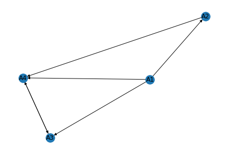

```python
import numpy as np


page_lst = ["A1", "A2", "A3", "A4"]
pageG = nx.DiGraph()
pageG.add_nodes_from(page_lst)
pageG.add_edges_from([('A1', 'A2'), ('A1', 'A3'), ('A1', 'A4'), ('A3', 'A4'), ('A2', 'A4'),('A4', 'A3'),])
nx.draw(pageG, with_labels=True)
plt.show()
```

```python
prs = nx.pagerank(pageG)
print ('Page rank scores: ', prs)
```

```
Page rank scores:  {'A1': 0.037500000000000006, 'A2': 0.04812500000000001, 'A3': 0.44613263460763297, 'A4': 0.4682423653923672}
```